# Association Between Oral Health and Dietary Habits in US Adults: An Analysis of NHANES Data

Kira Nightingale

### Overview

The goal of this project is to assess whether adult dietary habits have an impact on oral health in adults. Data from NHANES years 2015-2016 and 2017-2018 will be analyzed, including the demographic survey, dental examination, and dietary survey. For this project, I was advised by: Dr. Blanca Himes (Penn Medicine, informatics), who provided guidance on R code; Dr. Kevin Lynch (Penn Medicine, biostatistics), who provided guidance on statistical methods; and Jana Yablonski (Penn Dental Medicine, dental hygiene), who provided guidance on oral health concepts.

The project can be found via this GitHub link: https://github.com/kira-nightingale/BMIN503_Final_Project

### Introduction

The 2017 Global Burden of Disease Study estimated that approximately 3.5 billion individuals worldwide suffer from oral conditions including carious lesions and periodontal disease, resulting in 18.3 millions years lived with disability globally [1]. A study on the economic impact of oral diseases found that the direct and indirect costs associated with poor oral health result in global losses of around $442 billion in 2010. Notably, the estimated indirect costs amounted to $144 billion, a figure within the range of the indirect cost losses of the top ten global causes of death (ranging from $859 billion for cancer to $126 billion for lower respiratory infections) [2]. As with all health conditions, prevention is far preferable to treatment. A 10-year follow-up on the 2007 WHO World Health Assembly resolution calling for a focus on oral health promotion and disease prevention [3] found that prevention programs were most frequently targeted at children, with few efforts aimed at improving the oral health of adolescents and adults [4]. This is in some ways counter-intuitive, as in middle- and high-income countries, the burden of oral disease falls primarily on adults [5]. Therefore, determining how significant the role of diet is on oral health in adults could potentially provide an avenue for future adult-focused public health campaigns.

### Methods

First, the necessary libraries were loaded. Data from the 2015-2016 and 2017-2018 years were loaded, and the instruments were combined across years to increase the sample size.

```r
#Loading libraries
library(nhanesA)
library(SASxport)
library(plyr)
library(dplyr)
library(ggplot2)
library(table1)
library(labelled)
library(gtsummary)

#Loading data - 2015-2016 and 2017-2018
demog15 <- read.xport("C:/Users/nighki01/Box Sync/Course Materials/2021 Fall_Biomedical Informatics/BMIN503_Final_Project/Data/15-16.DEMO_I.XPT")
exam15 <- read.xport("C:/Users/nighki01/Box Sync/Course Materials/2021 Fall_Biomedical Informatics/BMIN503_Final_Project/Data/15-16.OHXDEN_I.XPT")
nutritiond115 <- read.xport("C:/Users/nighki01/Box Sync/Course Materials/2021 Fall_Biomedical Informatics/BMIN503_Final_Project/Data/15-16.DR1TOT_I.XPT")
nutritiond215 <- read.xport("C:/Users/nighki01/Box Sync/Course Materials/2021 Fall_Biomedical Informatics/BMIN503_Final_Project/Data/15-16.DR2TOT_I.XPT")

demog17 <- read.xport("C:/Users/nighki01/Box Sync/Course Materials/2021 Fall_Biomedical Informatics/BMIN503_Final_Project/Data/17-18.DEMO_J.XPT")
exam17 <- read.xport("C:/Users/nighki01/Box Sync/Course Materials/2021 Fall_Biomedical Informatics/BMIN503_Final_Project/Data/17-18.OHXDEN_J.XPT")
nutritiond117 <- read.xport("C:/Users/nighki01/Box Sync/Course Materials/2021 Fall_Biomedical Informatics/BMIN503_Final_Project/Data/17-18.DR1TOT_J.XPT")
nutritiond217 <- read.xport("C:/Users/nighki01/Box Sync/Course Materials/2021 Fall_Biomedical Informatics/BMIN503_Final_Project/Data/17-18.DR2TOT_J.XPT")

#Combining instruments across years
demog <- full_join(demog15, demog17)
nutritiond1 <- full_join(nutritiond115, nutritiond117)
nutritiond2 <- full_join(nutritiond215, nutritiond217)
nutrition <- full_join(nutritiond1, nutritiond2)
```

Next, the demographic data was cleaned by computing new values, renaming variables, and removing unneeded variables. Individuals were assigned to age groups in 10 year increments.

```r
demog <- demog %>%
  select(SEQN, RIAGENDR, RIDAGEYR, RIDRETH3, DMDEDUC2, DMDEDUC3, DMDMARTL,
         INDHHIN2, INDFMPIR) %>%
  mutate(age.grp = ifelse(RIDAGEYR %in% 10:19, "10-19",
                    ifelse(RIDAGEYR %in% 20:29, "20-29",
                           ifelse(RIDAGEYR %in% 30:39, "30-39",
                                  ifelse(RIDAGEYR %in% 40:49, "40-49",
                                         ifelse(RIDAGEYR %in% 50:59, "50-59",
                                                ifelse(RIDAGEYR %in% 60:69, "60-69",
                                                       ifelse(RIDAGEYR %in% 70:79, "70-79",
                                                              ifelse(RIDAGEYR >79, "80+", "<10"))))))))) %>%
  rename(gender = RIAGENDR, race = RIDRETH3, child.edu = DMDEDUC3, adult.edu =
           DMDEDUC2, marital = DMDMARTL, income = INDHHIN2, poverty = INDFMPIR)
```

The Decayed, Missing, Filled Tooth (DMFT) score is a commonly used indicator of tooth health used in dental research. In adults, all teeth except for third molars are assessed for caries, fillings, and missingness due to caries, and assigned a score of either 1 (presence of the aforementioned criteria) or 0 (sound, or missing due to other causes). The DMFT score is a summation of the 1 and 0 values for the full mouth. NHANES examiners assigned each tooth a letter value indicating its status. These letter values were re-coded to either 0 or 1 so that a DMFT score could be calculated for each participant. Root tips were not included as part of this calculation.

```r
#Dropping rows with incomplete exams
exam15 <- subset(exam15, OHDEXSTS!=3 & OHDEXSTS!=2)
exam17 <- subset(exam17, OHDEXSTS!=3 & OHDEXSTS!=2)

#Creating new variables with 0 or 1 values
for (i in 37:64) {
  newname <- paste0(names(exam15)[i], "new")
  exam15 <- mutate(exam15, !!newname := ifelse(!!as.name(names(exam15)[i])
                              %in% c("E", "F", "K", "P", "R", "Z", "A"), 1, 0))
}

for (i in 37:64) {
  newname <- paste0(names(exam17)[i], "new")
  exam17 <- mutate(exam17, !!newname := ifelse(!!as.name(names(exam17)[i])
                              %in% c("E", "F", "K", "P", "R", "Z", "A"), 1, 0))
}

#Calculating DMFT
exam15$dmft <- exam15 %>%
  select(171:198) %>%
  rowSums()

exam17$dmft <- exam17 %>%
  select(171:198) %>%
  rowSums()

#Selecting necessary variables and joining the datasets for the 2 years
exam15 <- select(exam15, SEQN, dmft)
exam17 <- select(exam17, SEQN, dmft)
exam <- full_join(exam15, exam17)

#Generating binary DMFT score variable and square root of DMFT for analysis
exam <- exam %>%
  mutate(dmft1 = ifelse(dmft>=1, 1, 0)) %>%
  mutate(dmft_sqrt = sqrt(dmft))
```

Nutrition data was obtained by NHANES through participant interviews. Participants were asked to report all foods eaten over a period of one or two days. Using an FDA database, NHANES personnel itemized comprehensive nutrition information for all foods eaten. For this project, the total values for relevant nutrients were used. First, participants with incomplete or not done nutrition profiles were removed. Then, the average quantity of nutrients was calculated for each participant. Finally, the amount of each nutrient consumed was compared to the Recommended Dietary Allowance (RDA) based on age and gender, and the applicable percentage was calculated.[6]

```r
#Removing participants with incomplete/not done nutrition profiles, and merging nutrition data with demographic information
data <-  full_join(demog, nutrition, by = "SEQN")
data <- subset(data, age.grp!="<10" & age.grp!="10-19")

data <- data %>%
  subset(DR1DRSTZ == 1 | DR2DRSTZ == 1) %>%
  select(SEQN, DRDINT, DR1TNUMF, DR2TNUMF, DR1TKCAL, DR1TPROT, DR1TCARB,
         DR1TSUGR, DR1TFIBE, DR1TTFAT, DR1TSFAT, DR1TCHOL, DR1TATOC, DR1TVARA,
         DR1TVB1, DR1TVB2, DR1TVB6, DR1TVB12, DR1TVC, DR1TVD, DR1TVK, DR1TCALC,
         DR1TIRON, DR1.300, DR1.320Z, DR2TKCAL, DR2TPROT, DR2TCARB, DR2TSUGR,
         DR2TFIBE, DR2TTFAT, DR2TSFAT, DR2TCHOL, DR2TATOC, DR2TVARA, DR2TVB1,
         DR2TVB2, DR2TVB6, DR2TVB12, DR2TVC, DR2TVD, DR2TVK, DR2TCALC, DR2TIRON,
         DR2.300, DR2.320Z, gender, race, child.edu, adult.edu, marital, income,
         poverty, age.grp)



#Averaging nutrient intake per participant
data$calories <- rowMeans(subset(data, select = c(DR1TKCAL, DR2TKCAL)), na.rm = TRUE)
data$protein <- rowMeans(subset(data, select = c(DR1TPROT, DR2TPROT)), na.rm = TRUE)
data$carbs <- rowMeans(subset(data, select = c(DR1TCARB, DR2TCARB)), na.rm = TRUE)
data$sugar <- rowMeans(subset(data, select = c(DR1TSUGR, DR2TSUGR)), na.rm = TRUE)
data$fiber <- rowMeans(subset(data, select = c(DR1TFIBE, DR2TFIBE)), na.rm = TRUE)
data$fat <- rowMeans(subset(data, select = c(DR1TTFAT, DR2TTFAT)), na.rm = TRUE)
data$satfat <- rowMeans(subset(data, select = c(DR1TSFAT, DR2TSFAT)), na.rm = TRUE)
data$cholesterol <- rowMeans(subset(data, select = c(DR1TCHOL, DR2TCHOL)), na.rm = TRUE)
data$vit.e <- rowMeans(subset(data, select = c(DR1TATOC, DR2TATOC)), na.rm = TRUE)
data$vit.a <- rowMeans(subset(data, select = c(DR1TVARA, DR2TVARA)), na.rm = TRUE)
data$vit.b1 <- rowMeans(subset(data, select = c(DR1TVB1, DR2TVB1)), na.rm = TRUE)
data$vit.b2 <- rowMeans(subset(data, select = c(DR1TVB2, DR2TVB2)), na.rm = TRUE)
data$vit.b6 <- rowMeans(subset(data, select = c(DR1TVB6, DR2TVB6)), na.rm = TRUE)
data$vit.b12 <- rowMeans(subset(data, select = c(DR1TVB12, DR2TVB12)), na.rm = TRUE)
data$vit.c <- rowMeans(subset(data, select = c(DR1TVC, DR2TVC)), na.rm = TRUE)
data$vit.d <- rowMeans(subset(data, select = c(DR1TVD, DR2TVD)), na.rm = TRUE)
data$vit.k <- rowMeans(subset(data, select = c(DR1TVK, DR2TVK)), na.rm = TRUE)
data$calcium <- rowMeans(subset(data, select = c(DR1TCALC, DR2TCALC)), na.rm = TRUE)
data$iron <- rowMeans(subset(data, select = c(DR1TIRON, DR2TIRON)), na.rm = TRUE)
data$water <- rowMeans(subset(data, select = c(DR1.320Z, DR2.320Z)), na.rm = TRUE)

data <- data %>%
  select(SEQN, DRDINT, DR1TNUMF, DR2TNUMF, DR1.300, DR2.300, calories, protein,
         carbs, sugar, fiber, fat, satfat, cholesterol, vit.e, vit.a, vit.b1,
         vit.b2, vit.b6, vit.b12, vit.c, vit.d, vit.k, calcium, iron, water,
         gender, race, child.edu, adult.edu, marital, income, poverty, age.grp)

#Calculating percent daily values based on age and gender
data <- data %>%
  mutate(p.calories = if_else(gender==1 & age.grp=="20-29", (calories/2400)*100,
                             if_else(gender==2 & age.grp=="20-29", (calories/2000)*100,
                                    if_else(gender==1 & age.grp=="30-39" | age.grp=="40-49", (calories/2200)*100,
                                           if_else(gender==2 & age.grp=="30-39" | age.grp=="40-49", (calories/1800)*100,
                                                  if_else(gender==1 & age.grp=="50-59" | age.grp=="60-69" | age.grp=="70-79" | age.grp=="80+", (calories/2000)*100, (calories/1600)*100)))))) %>%
  mutate(p.protein = if_else(gender==1, (protein/56)*100, (protein/56)*100)) %>%
  mutate(p.carbs = (carbs/130)*100) %>%
  mutate(p.sugar = if_else(gender==1, (sugar/36)*100, (sugar/24)*100)) %>%
  mutate(p.fiber = if_else(gender==1 & age.grp=="20-29", (fiber/34)*100,
                             if_else(gender==2 & age.grp=="20-29", (fiber/28)*100,
                                    if_else(gender==1 & age.grp=="30-39" | age.grp=="40-49", (fiber/31)*100,
                                           if_else(gender==2 & age.grp=="30-39" | age.grp=="40-49", (fiber/25)*100,
                                                  if_else(gender==1 & age.grp=="50-59" | age.grp=="60-69" | age.grp=="70-79" | age.grp=="80+", (fiber/28)*100, (fiber/22)*100)))))) %>%
  mutate(p.fat = (fat/35)*100) %>%
  mutate(p.satfat = ((satfat/calories)/0.1)*100) %>%
  mutate(p.vit.e = (vit.e/15)*100) %>%
  mutate(p.vit.a = if_else(gender==1, (vit.a/900)*100, (vit.a/700)*100)) %>%
  mutate(p.vit.b6 = if_else(gender==1 & age.grp=="50-59" | age.grp=="60-69" | age.grp=="70-79" | age.grp=="80+", (vit.b6/1.7)*100,
                            if_else(gender==2 & age.grp=="50-59" | age.grp=="60-69" | age.grp=="70-79" | age.grp=="80+", (vit.b6/1.5)*100, (vit.b6/1.3)*100))) %>%
  mutate(p.vit.b12 = (vit.b12/2.4)*100) %>%
  mutate(p.vit.c = if_else(gender==1, (vit.c/90)*100, (vit.c/75)*100)) %>%
  mutate(p.vit.d = if_else(age.grp=="70-79" | age.grp=="80+", (vit.d/800)*100, (vit.d/600)*100)) %>%
  mutate(p.vit.k = if_else(gender==1, (vit.k/120)*100, (vit.k/90)*100)) %>%
  mutate(p.calcium = if_else(gender==1 & age.grp=="70-79" | age.grp=="80+", (calcium/1200)*100,
                             if_else(gender==2 & age.grp=="50-59" | age.grp=="60-69" | age.grp=="70-79" | age.grp=="80+", (calcium/1200)*100, (calcium/1000)*100))) %>%
  mutate(p.iron = if_else(gender==2 & age.grp=="20-29" | age.grp=="30-39" | age.grp=="40-49", (iron/18)*100, (iron/8)*100))

data$age.grp <- as.factor(data$age.grp)

#Scaling percent values in 5% increments for analysis
for (i in 35:50) {
  scaled <- paste0(names(data)[i], "scaled")
  data <- mutate(data, !!scaled := (!!as.name(names(data)[i])/5))
}
```

Finally, all remaining data files were combined into a single data frame, and cases that included both nutrition data and DMFT score were included in the final data set. Methods for analysis, the applicable code, and outputs are included in the Results section below.

```r
#Merging data into a single data frame
data <-  join_all(list(data, exam), by = "SEQN", type = "full")
data <- data[!is.na(data$calories), ]
data <- data[!is.na(data$dmft), ]
```

### Results

The below table shows the demographic distribution of the population, broken down by age group. The population includes a slightly greater number of females than males. Non-Hispanic whites made up 35% of the population, followed by non-Hispanic blacks (22.4%), Mexican Americans (15.3%), Asians (11.6%), non-Mexican Hispanic (11.2%), and other (4.3%).The mean income for the study population was approximately 2.52 times the national poverty level.

```r
#Labeling factor data and variable names
data$gender <- factor(data$gender, levels=c(1, 2), labels=c("Male", "Female"))
data$race <- factor(data$race, levels=c(3, 4, 6, 1, 2, 7), labels=c("White,
                              Non-Hispanic", "Black, Non-Hispanic", "Asian,
                              Non-Hispanic", "Mexican American", "Other Hispanic",
                              "Other/Multi-Race"))
data$adult.edu <- factor(data$adult.edu, levels=c(1, 2, 3, 4, 5, 7, 9),
                         labels=c("Less than 9th grade", "Some highschool",
                                  "Highschool/GED or equivalent",
                                  "Some college/Associates degree",
                                  "College graduate or above", "Refused",
                                  "Don't know"))
data$marital <- factor(data$marital, levels=c(1, 2, 3, 4, 5, 6, 77),
                       labels=c("Married", "Widowed", "Divorced", "Separated",
                                "Never married", "Living with partner", "Refused"))

label(data$age.grp) <- "Age Group"
label(data$gender) <- "Sex"
label(data$race) <- "Race"
label(data$adult.edu) <- "Education Level"
label(data$marital) <- "Marital Status"

#Creating a function to show mean (SD) for continuous variables in the table
my.render.cont <- function(x) {
    with(stats.apply.rounding(stats.default(x), digits=3), c("",
        "Mean (SD)"=sprintf("%s (&plusmn; %s)", MEAN, SD)))
}

#Generating Table 1
table1(~gender + race + adult.edu + poverty | age.grp, data=data,
       overall="Total", render.continuous=my.render.cont)
```

|  | 20-29 (N=1504) | 30-39 (N=1527) | 40-49 (N=1478) | 50-59 (N=1568) | 60-69 (N=1793) | 70-79 (N=1014) | 80+ (N=602) | Total (N=9486) |
| --- | --- | --- | --- | --- | --- | --- | --- | --- |
| Sex |  |  |  |  |  |  |  |  |
| Male | 720 (47.9%) | 722 (47.3%) | 691 (46.8%) | 753 (48.0%) | 904 (50.4%) | 534 (52.7%) | 291 (48.3%) | 4615 (48.7%) |
| Female | 784 (52.1%) | 805 (52.7%) | 787 (53.2%) | 815 (52.0%) | 889 (49.6%) | 480 (47.3%) | 311 (51.7%) | 4871 (51.3%) |
| Race |  |  |  |  |  |  |  |  |
| White, Non-Hispanic | 470 (31.3%) | 486 (31.8%) | 447 (30.2%) | 496 (31.6%) | 516 (28.8%) | 488 (48.1%) | 420 (69.8%) | 3323 (35.0%) |
| Black, Non-Hispanic | 340 (22.6%) | 321 (21.0%) | 362 (24.5%) | 358 (22.8%) | 481 (26.8%) | 183 (18.0%) | 84 (14.0%) | 2129 (22.4%) |
| Asian, Non-Hispanic | 201 (13.4%) | 212 (13.9%) | 215 (14.5%) | 205 (13.1%) | 172 (9.6%) | 77 (7.6%) | 23 (3.8%) | 1105 (11.6%) |
| Mexican American | 268 (17.8%) | 252 (16.5%) | 241 (16.3%) | 240 (15.3%) | 295 (16.5%) | 125 (12.3%) | 32 (5.3%) | 1453 (15.3%) |
| Other Hispanic | 154 (10.2%) | 169 (11.1%) | 136 (9.2%) | 204 (13.0%) | 272 (15.2%) | 100 (9.9%) | 31 (5.1%) | 1066 (11.2%) |
| Other/Multi-Race | 71 (4.7%) | 87 (5.7%) | 77 (5.2%) | 65 (4.1%) | 57 (3.2%) | 41 (4.0%) | 12 (2.0%) | 410 (4.3%) |
| Education Level |  |  |  |  |  |  |  |  |
| Less than 9th grade | 48 (3.2%) | 114 (7.5%) | 123 (8.3%) | 145 (9.2%) | 246 (13.7%) | 138 (13.6%) | 79 (13.1%) | 893 (9.4%) |
| Some highschool | 151 (10.0%) | 180 (11.8%) | 168 (11.4%) | 174 (11.1%) | 207 (11.5%) | 109 (10.7%) | 87 (14.5%) | 1076 (11.3%) |
| Highschool/GED or equivalent | 400 (26.6%) | 292 (19.1%) | 292 (19.8%) | 384 (24.5%) | 422 (23.5%) | 242 (23.9%) | 155 (25.7%) | 2187 (23.1%) |
| Some college/Associates degree | 553 (36.8%) | 493 (32.3%) | 467 (31.6%) | 488 (31.1%) | 520 (29.0%) | 283 (27.9%) | 165 (27.4%) | 2969 (31.3%) |
| College graduate or above | 352 (23.4%) | 448 (29.3%) | 427 (28.9%) | 377 (24.0%) | 395 (22.0%) | 240 (23.7%) | 113 (18.8%) | 2352 (24.8%) |
| Refused | 0 (0%) | 0 (0%) | 1 (0.1%) | 0 (0%) | 1 (0.1%) | 0 (0%) | 0 (0%) | 2 (0.0%) |
| Don't know | 0 (0%) | 0 (0%) | 0 (0%) | 0 (0%) | 2 (0.1%) | 2 (0.2%) | 3 (0.5%) | 7 (0.1%) |
| Ratio of family income to poverty |  |  |  |  |  |  |  |  |
| Mean (SD) | 2.29 (± 1.53) | 2.41 (± 1.59) | 2.69 (± 1.65) | 2.75 (± 1.70) | 2.48 (± 1.60) | 2.53 (± 1.53) | 2.38 (± 1.42) | 2.52 (± 1.60) |
| Missing | 147 (9.8%) | 130 (8.5%) | 130 (8.8%) | 170 (10.8%) | 220 (12.3%) | 118 (11.6%) | 90 (15.0%) | 1005 (10.6%) |

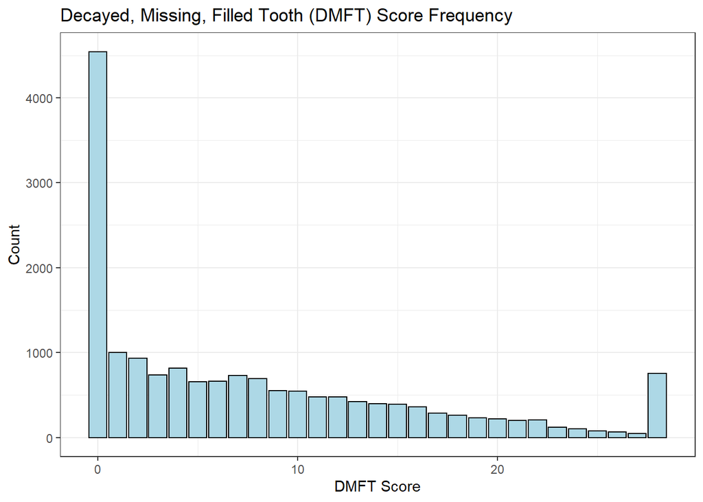

```r
ggplot(data=exam, aes(dmft)) +
  geom_bar(fill="lightblue", color="black") +
  labs(title = "Decayed, Missing, Filled Tooth (DMFT) Score Frequency",
       x = "DMFT Score", y = "Count") +
  theme_bw()
```

Looking at the DMFT trends in the different age groups, there is large variation within groups. However, there is a clear trend of increasing DMFT as age increases, which is statistically significant across all comparisons. Intuitively, this makes sense as DMFT measures both current and prior caries experience. DMFT score can therefore never decease, only stay the same or increase over time.

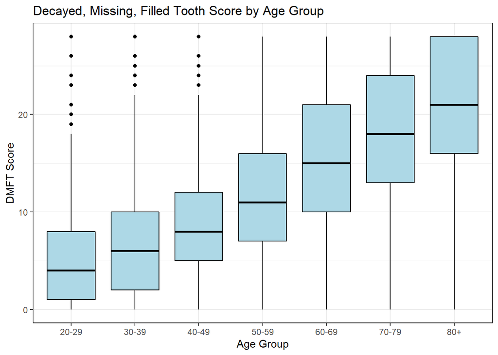

```r
#Box plot DMFT by age group
ggplot(data, aes(age.grp, dmft)) +
  geom_boxplot(fill = "lightblue", color="black") +
  labs(title = "Decayed, Missing, Filled Tooth Score by Age Group",
       x = "Age Group", y= "DMFT Score") +
  theme_bw()
```

```r
#ANOVA and Tukey post-hoc test
anova <- aov(dmft ~ age.grp, data=data)
summary(anova)
```

```
##               Df Sum Sq Mean Sq F value Pr(>F)
## age.grp        6 233980   38997   962.6 <2e-16 ***
## Residuals   9479 384011      41
## ---
## Signif. codes:  0 '***' 0.001 '**' 0.01 '*' 0.05 '.' 0.1 ' ' 1
```

```r
posthoc <- TukeyHSD(anova)
posthoc
```

```
##   Tukey multiple comparisons of means
##     95% family-wise confidence level
##
## Fit: aov(formula = dmft ~ age.grp, data = data)
##
## $age.grp
##                  diff       lwr       upr p adj
## 30-39-20-29  1.798672  1.116792  2.480553     0
## 40-49-20-29  4.012064  3.324598  4.699531     0
## 50-59-20-29  7.221762  6.544320  7.899205     0
## 60-69-20-29 10.544592  9.888290 11.200895     0
## 70-79-20-29 13.248113 12.485430 14.010795     0
## 80+-20-29   15.723720 14.818476 16.628964     0
## 40-49-30-39  2.213392  1.528497  2.898288     0
## 50-59-30-39  5.423090  4.748257  6.097924     0
## 60-69-30-39  8.745920  8.092311  9.399529     0
## 70-79-30-39 11.449441 10.689075 12.209806     0
## 80+-30-39   13.925048 13.021755 14.828341     0
## 50-59-40-49  3.209698  2.529221  3.890175     0
## 60-69-40-49  6.532528  5.873093  7.191963     0
## 70-79-40-49  9.236049  8.470669 10.001428     0
## 80+-40-49   11.711656 10.804138 12.619173     0
## 60-69-50-59  3.322830  2.673852  3.971808     0
## 70-79-50-59  6.026350  5.269962  6.782739     0
## 80+-50-59    8.501958  7.602010  9.401906     0
## 70-79-60-69  2.703520  1.966005  3.441035     0
## 80+-60-69    5.179128  4.294983  6.063272     0
## 80+-70-79    2.475607  1.509863  3.441352     0
```

Consumption of sugar and carbohydrates has been associated with increased caries risk due to the resulting change in oral pH that promotes cariogenic bacteria growth.[7] Conversely, inadequate amounts of protein and vitamin C have been linked to periodontal disease, which in turn may lead to increased dental decay due to exposure of the root surfaces. [8] Calcium and vitamin D have also been cited as important nutrients for tooth health, particularly in children. [9] Therefore, to investigate the effects of diet on DMFT score, nutrient information was limited to include total calories, sugar, carbohydrates, protein, vitamin C, calcium, and vitamin D. A summary of the average nutrient consumption by sex and by sex and age group can be found below. We can see that most age groups consume close to the RDV of calories and vitamin C on a daily basis. Consumption of carbohydrates and protein is generally higher than recommended, whereas average sugar consumption is over 300% of the recommended quantities for males and females. Notably, consumption of vitamin D across all age groups is negligible. This could be due to the fact that the primary foods containing vitamin D are fortified milk, juices, and cereals, and the majority of US adults receive the bulk of their vitamin D requirements from vitamin supplements [10], which were not accounted for in this analysis.

```r
label(data$p.calories) <- "% RDV Calories"
label(data$p.sugar) <- "% RDV Sugar"
label(data$p.carbs) <- "% RDV Carbs"
label(data$p.protein) <- "% RDV Protein"
label(data$p.vit.c) <- "% RDV Vitamin C"
label(data$p.vit.d) <- "% RDV Vitamin D"
label(data$p.calcium) <- "% RDV Calcium"
table1(~p.calories + p.sugar + p.carbs + p.protein + p.vit.c + p.calcium +
         p.vit.d | gender, data=data, overall="Total")
```

|  | Male (N=4615) | Female (N=4871) | Total (N=9486) |
| --- | --- | --- | --- |
| % RDV Calories |  |  |  |
| Mean (SD) | 109 (43.0) | 90.9 (35.4) | 99.8 (40.3) |
| Median [Min, Max] | 104 [5.64, 416] | 86.1 [11.4, 381] | 94.7 [5.64, 416] |
| % RDV Sugar |  |  |  |
| Mean (SD) | 311 (202) | 377 (213) | 345 (210) |
| Median [Min, Max] | 272 [3.81, 2720] | 337 [6.98, 1990] | 305 [3.81, 2720] |
| % RDV Carbs |  |  |  |
| Mean (SD) | 207 (91.7) | 161 (65.2) | 184 (82.5) |
| Median [Min, Max] | 195 [16.9, 940] | 154 [7.62, 635] | 172 [7.62, 940] |
| % RDV Protein |  |  |  |
| Mean (SD) | 162 (70.2) | 120 (49.7) | 141 (64.0) |
| Median [Min, Max] | 151 [2.93, 662] | 114 [2.77, 513] | 131 [2.77, 662] |
| % RDV Vitamin C |  |  |  |
| Mean (SD) | 93.7 (95.8) | 101 (87.9) | 97.3 (91.9) |
| Median [Min, Max] | 65.9 [0, 1210] | 77.3 [0, 1010] | 71.9 [0, 1210] |
| % RDV Calcium |  |  |  |
| Mean (SD) | 93.7 (54.2) | 73.5 (38.2) | 83.4 (47.7) |
| Median [Min, Max] | 82.5 [4.58, 722] | 66.8 [3.83, 355] | 74.1 [3.83, 722] |
| % RDV Vitamin D |  |  |  |
| Mean (SD) | 0.776 (0.811) | 0.642 (0.677) | 0.707 (0.748) |
| Median [Min, Max] | 0.558 [0, 8.91] | 0.467 [0, 8.26] | 0.500 [0, 8.91] |

```r
table1(~p.calories + p.sugar + p.carbs + p.protein + p.vit.c + p.calcium +
         p.vit.d | age.grp + gender, data=data, overall="Total")
```

|  | 20-29 Male (N=720) | 20-29 Female (N=784) | 30-39 Male (N=722) | 30-39 Female (N=805) | 40-49 Male (N=691) | 40-49 Female (N=787) | 50-59 Male (N=753) | 50-59 Female (N=815) | 60-69 Male (N=904) | 60-69 Female (N=889) | 70-79 Male (N=534) | 70-79 Female (N=480) | 80+ Male (N=291) | 80+ Female (N=311) | Total Male (N=4615) | Total Female (N=4871) |
| --- | --- | --- | --- | --- | --- | --- | --- | --- | --- | --- | --- | --- | --- | --- | --- | --- |
| % RDV Calories |  |  |  |  |  |  |  |  |  |  |  |  |  |  |  |  |
| Mean (SD) | 102 (44.2) | 93.7 (35.4) | 116 (45.9) | 102 (37.9) | 112 (42.0) | 82.2 (29.7) | 118 (44.5) | 107 (39.2) | 108 (42.3) | 82.6 (31.1) | 102 (37.9) | 78.5 (28.7) | 95.8 (33.6) | 78.5 (25.9) | 109 (43.0) | 90.9 (35.4) |
| Median [Min, Max] | 97.0 [10.5, 354] | 88.5 [11.4, 381] | 111 [5.64, 380] | 99.5 [15.6, 276] | 105 [20.0, 372] | 79.9 [18.4, 236] | 114 [23.3, 405] | 105 [17.6, 312] | 102 [14.8, 416] | 78.2 [11.4, 233] | 98.3 [15.3, 300] | 75.9 [11.8, 181] | 92.0 [25.6, 208] | 76.7 [28.3, 201] | 104 [5.64, 416] | 86.1 [11.4, 381] |
| % RDV Sugar |  |  |  |  |  |  |  |  |  |  |  |  |  |  |  |  |
| Mean (SD) | 324 (208) | 399 (234) | 343 (230) | 390 (221) | 327 (216) | 401 (218) | 318 (223) | 369 (210) | 285 (169) | 350 (205) | 272 (162) | 350 (180) | 285 (156) | 371 (189) | 311 (202) | 377 (213) |
| Median [Min, Max] | 287 [17.7, 1670] | 350 [6.98, 1620] | 296 [6.19, 1820] | 338 [20.2, 1990] | 286 [18.0, 2480] | 368 [19.4, 1690] | 278 [10.6, 2720] | 331 [25.5, 1800] | 256 [3.81, 1210] | 301 [23.4, 1280] | 242 [9.50, 1680] | 324 [14.1, 1110] | 263 [29.8, 1080] | 344 [82.1, 1470] | 272 [3.81, 2720] | 337 [6.98, 1990] |
| % RDV Carbs |  |  |  |  |  |  |  |  |  |  |  |  |  |  |  |  |
| Mean (SD) | 221 (101) | 172 (70.3) | 228 (99.6) | 170 (68.8) | 219 (91.7) | 168 (64.8) | 210 (93.5) | 159 (65.0) | 195 (81.5) | 153 (62.1) | 182 (77.0) | 149 (57.4) | 177 (69.8) | 150 (54.4) | 207 (91.7) | 161 (65.2) |
| Median [Min, Max] | 207 [31.1, 690] | 160 [17.8, 635] | 215 [19.5, 800] | 164 [7.62, 426] | 206 [19.3, 810] | 164 [22.4, 425] | 198 [28.6, 940] | 152 [23.6, 567] | 184 [16.9, 818] | 144 [11.9, 427] | 172 [20.3, 736] | 145 [9.60, 397] | 170 [29.0, 488] | 142 [56.4, 478] | 195 [16.9, 940] | 154 [7.62, 635] |
| % RDV Protein |  |  |  |  |  |  |  |  |  |  |  |  |  |  |  |  |
| Mean (SD) | 173 (80.7) | 128 (54.7) | 178 (76.7) | 127 (53.0) | 173 (68.7) | 125 (51.8) | 166 (71.2) | 119 (46.5) | 152 (62.3) | 116 (47.3) | 139 (54.5) | 110 (43.9) | 129 (47.7) | 104 (36.2) | 162 (70.2) | 120 (49.7) |
| Median [Min, Max] | 161 [12.3, 600] | 121 [4.61, 513] | 166 [2.93, 559] | 121 [2.77, 372] | 162 [5.79, 575] | 119 [9.03, 384] | 157 [24.2, 662] | 115 [7.34, 314] | 143 [19.9, 471] | 108 [10.8, 459] | 132 [9.71, 409] | 105 [14.4, 266] | 124 [33.1, 331] | 103 [30.9, 222] | 151 [2.93, 662] | 114 [2.77, 513] |
| % RDV Vitamin C |  |  |  |  |  |  |  |  |  |  |  |  |  |  |  |  |
| Mean (SD) | 92.8 (107) | 97.3 (93.6) | 98.4 (110) | 99.5 (87.2) | 94.9 (93.6) | 101 (82.4) | 95.1 (97.2) | 101 (91.6) | 91.8 (84.7) | 104 (92.2) | 89.8 (81.9) | 102 (80.8) | 90.9 (86.9) | 99.1 (75.4) | 93.7 (95.8) | 101 (87.9) |
| Median [Min, Max] | 57.4 [0.444, 937] | 70.5 [0.200, 1010] | 67.5 [0, 1210] | 77.3 [0, 636] | 66.8 [0, 789] | 78.9 [0.267, 536] | 65.2 [0, 741] | 77.1 [0, 770] | 68.5 [0.0556, 832] | 78.0 [0, 810] | 69.8 [0, 787] | 79.8 [2.73, 541] | 67.1 [0, 616] | 80.8 [0, 393] | 65.9 [0, 1210] | 77.3 [0, 1010] |
| % RDV Calcium |  |  |  |  |  |  |  |  |  |  |  |  |  |  |  |  |
| Mean (SD) | 108 (62.9) | 85.3 (41.5) | 112 (63.2) | 84.6 (41.9) | 102 (49.7) | 83.2 (42.2) | 98.0 (54.5) | 66.3 (32.2) | 76.2 (41.8) | 62.5 (31.2) | 74.0 (38.9) | 59.7 (28.7) | 73.0 (38.1) | 62.7 (29.9) | 93.7 (54.2) | 73.5 (38.2) |
| Median [Min, Max] | 95.1 [8.30, 722] | 78.9 [6.40, 307] | 102 [9.10, 502] | 78.2 [5.10, 263] | 93.6 [5.90, 311] | 77.2 [9.40, 355] | 88.0 [12.7, 520] | 62.7 [5.83, 238] | 69.7 [4.58, 381] | 57.3 [3.83, 254] | 65.8 [8.21, 255] | 56.0 [7.42, 184] | 68.8 [6.50, 268] | 58.5 [5.92, 195] | 82.5 [4.58, 722] | 66.8 [3.83, 355] |
| % RDV Vitamin D |  |  |  |  |  |  |  |  |  |  |  |  |  |  |  |  |
| Mean (SD) | 0.789 (0.881) | 0.661 (0.693) | 0.810 (0.865) | 0.658 (0.645) | 0.777 (0.684) | 0.662 (0.700) | 0.810 (0.825) | 0.669 (0.746) | 0.820 (0.928) | 0.666 (0.737) | 0.633 (0.608) | 0.518 (0.503) | 0.697 (0.621) | 0.557 (0.463) | 0.776 (0.811) | 0.642 (0.677) |
| Median [Min, Max] | 0.521 [0, 7.19] | 0.492 [0, 8.26] | 0.567 [0, 7.65] | 0.500 [0, 5.35] | 0.600 [0, 4.33] | 0.483 [0, 6.25] | 0.608 [0, 7.05] | 0.467 [0, 7.31] | 0.583 [0, 8.91] | 0.458 [0, 6.77] | 0.478 [0, 7.24] | 0.388 [0, 5.59] | 0.563 [0.0125, 5.29] | 0.444 [0, 2.94] | 0.558 [0, 8.91] | 0.467 [0, 8.26] |

To assess whether DMFT score is associated with diet, two separate analyses were performed. First, a logistic regression was run using a binomial outcome which indicated individuals with a DMFT score of 0 versus individuals with a DMFT score of 1 or greater. Then, a linear regression was run using the square root of all non-zero DMFT scores. For ease of interpretation, percent daily values were scaled to increments of 5%.

```r
#Logistic regression
logistic <- glm(dmft1 ~ p.caloriesscaled + p.carbsscaled + p.proteinscaled +
                  p.vit.cscaled + p.vit.dscaled + p.sugarscaled +
                  p.calciumscaled + age.grp + adult.edu + gender, data = data,
                family = binomial())

tbl_regression(logistic, exponentiate = TRUE, label =
                    list(p.caloriesscaled ~ "% RDV Calories (5% increments)",
                         p.sugarscaled ~ "% RDV Sugar (5% increments)",
                         p.carbsscaled ~ "% RDV Carbs (5% increments)",
                         p.proteinscaled ~ "% RDV Protein (5% increments)",
                         p.vit.cscaled ~ "% RDV Vitamin C (5% increments)",
                         p.vit.dscaled ~ "% RDV Vitamin D (5% increments)",
                         p.calciumscaled ~ "% RDV Calcium (5% increments)",
                         age.grp ~ "Age Group", adult.edu ~ "Education",
                         gender ~ "Gender"))
```

| **Characteristic** | **OR**<sup>1</sup> | **95% CI**<sup>1</sup> | **p-value** |
| --- | --- | --- | --- |
| % RDV Calories (5% increments) | 0.99 | 0.97, 1.02 | 0.7 |
| % RDV Carbs (5% increments) | 0.98 | 0.97, 1.00 | 0.017 |
| % RDV Protein (5% increments) | 1.00 | 0.99, 1.01 | 0.8 |
| % RDV Vitamin C (5% increments) | 1.00 | 0.99, 1.00 | 0.2 |
| % RDV Vitamin D (5% increments) | 0.86 | 0.48, 1.62 | 0.6 |
| % RDV Sugar (5% increments) | 1.01 | 1.01, 1.01 | <0.001 |
| % RDV Calcium (5% increments) | 1.01 | 1.00, 1.02 | 0.2 |
| Age Group |  |  |  |
| 20-29 | — | — |  |
| 30-39 | 1.73 | 1.41, 2.12 | <0.001 |
| 40-49 | 4.34 | 3.39, 5.60 | <0.001 |
| 50-59 | 10.6 | 7.52, 15.4 | <0.001 |
| 60-69 | 23.4 | 15.4, 37.4 | <0.001 |
| 70-79 | 21.5 | 12.9, 39.1 | <0.001 |
| 80+ | 55.2 | 20.9, 224 | <0.001 |
| Education |  |  |  |
| Less than 9th grade | — | — |  |
| Some highschool | 1.94 | 1.32, 2.87 | <0.001 |
| Highschool/GED or equivalent | 1.68 | 1.19, 2.34 | 0.002 |
| Some college/Associates degree | 1.75 | 1.26, 2.40 | <0.001 |
| College graduate or above | 1.12 | 0.81, 1.53 | 0.5 |
| Refused | 37,872 | 0.00, NA | >0.9 |
| Don't know | 11,577 | 0.00, NA | >0.9 |
| Gender |  |  |  |
| Male | — | — |  |
| Female | 1.19 | 0.96, 1.48 | 0.12 |

<sup>*1*</sup> OR = Odds Ratio, CI = Confidence Interval

```r
#Linear regression
linear <- glm(dmft_sqrt ~ p.caloriesscaled + p.carbsscaled + p.proteinscaled +
                p.vit.cscaled + p.vit.dscaled + p.sugarscaled + p.calciumscaled +
                age.grp + adult.edu + gender,
              data = subset(data, dmft_sqrt != 0), family = gaussian())

tbl_regression(linear, label =
                 list(p.caloriesscaled ~ "% RDV Calories (5% increments)",
                      p.sugarscaled ~ "% RDV Sugar (5% increments)",
                      p.carbsscaled ~ "% RDV Carbs (5% increments)",
                      p.proteinscaled ~ "% RDV Protein (5% increments)",
                      p.vit.cscaled ~ "% RDV Vitamin C (5% increments)",
                      p.vit.dscaled ~ "% RDV Vitamin D (5% increments)",
                      p.calciumscaled ~ "% RDV Calcium (5% increments)",
                      age.grp ~ "Age Group", adult.edu ~ "Education",
                      gender ~ "Gender"),
               estimate_fun = purrr::partial(style_ratio, digits = 3))
```

| **Characteristic** | **Beta** | **95% CI**<sup>1</sup> | **p-value** |
| --- | --- | --- | --- |
| % RDV Calories (5% increments) | 0.002 | -0.005, 0.009 | 0.5 |
| % RDV Carbs (5% increments) | -0.006 | -0.010, -0.003 | <0.001 |
| % RDV Protein (5% increments) | -0.003 | -0.006, 0.000 | 0.055 |
| % RDV Vitamin C (5% increments) | -0.002 | -0.003, -0.001 | <0.001 |
| % RDV Vitamin D (5% increments) | 0.047 | -0.108, 0.202 | 0.5 |
| % RDV Sugar (5% increments) | 0.004 | 0.003, 0.005 | <0.001 |
| % RDV Calcium (5% increments) | 0.001 | -0.002, 0.004 | 0.5 |
| Age Group |  |  |  |
| 20-29 | — | — |  |
| 30-39 | 0.323 | 0.248, 0.397 | <0.001 |
| 40-49 | 0.635 | 0.563, 0.707 | <0.001 |
| 50-59 | 1.080 | 1.003, 1.157 | <0.001 |
| 60-69 | 1.539 | 1.467, 1.611 | <0.001 |
| 70-79 | 1.913 | 1.832, 1.994 | <0.001 |
| 80+ | 2.167 | 2.073, 2.261 | <0.001 |
| Education |  |  |  |
| Less than 9th grade | — | — |  |
| Some highschool | 0.111 | 0.025, 0.197 | 0.011 |
| Highschool/GED or equivalent | 0.110 | 0.034, 0.186 | 0.005 |
| Some college/Associates degree | 0.076 | 0.002, 0.149 | 0.044 |
| College graduate or above | -0.120 | -0.196, -0.045 | 0.002 |
| Refused | 0.296 | -0.99, 1.583 | 0.7 |
| Don't know | 0.455 | -0.235, 1.145 | 0.2 |
| Gender |  |  |  |
| Male | — | — |  |
| Female | 0.038 | -0.012, 0.089 | 0.14 |

<sup>*1*</sup> CI = Confidence Interval

Interestingly, increased carbohydrate consumption was associated with a lower likelihood of having a DMFT score >0, and having fewer caries when the DMFT score was 1 or greater. This may be due to the fact that it is not just the quantity of sugar/carbohydrates you consume but the frequency at which they are consumed that impacts oral health. Even small amounts of sugar and carbohydrates consumed throughout the day can prolong the disruption in oral pH, thereby increasing the total length of time at risk for cariogenic bacteria growth. It is possible that if frequency of consumption was included in this analysis, the impact of carbohydrates on DMFT score would have been reversed.

There was no significant impact of calcium or vitamin D consumption on caries. This is likely due to the fact that calcium and vitamin D may have a larger impact on tooth health close to the time of eruption, and this study was limited to individuals aged 20 years and older.

### Conclusion

Based on the results of this analysis, it is clear that sugar consumption plays a large role in caries development even in adulthood. Notably, the risk of having at least one carie increases by 1% for each 5% RDV sugar consumed. The AHA recommends that adult females consume no more than 100 calories of sugar (24 grams) a day, and that males consume no more than 150 calories of sugar (36 grams) a day. [13] In females, this means that every additional 1.2 grams of sugar a day increases caries risk by 1%, an effect that quickly multiplies considering that the average woman in the study population reported consuming 90.5 grams per day. This finding is consistent with those of another project assessing the relationship between diet and oral health. [14] Consumption of Vitamin C was shown to be associated with lower DMFT score, perhaps pointing to the importance of rounded diets and daily multivitamin use.

The strongest association with oral health was age, a factor that is not modifiable. It is therefore important to identify additional risk factors for caries that could be targeted for effective interventions. Future analyses should consider whether the impact of diet can be modified through oral hygiene habits, a factor that could not be assessed using NHANES data. Limitations of this analysis include the fact that dietary recall is notoriously unreliable, and therefore nutrition data cannot be considered to be completely accurate. It is also known that not only quantity, but also frequency, of nutrient consumption plays a role in oral health, which was not assessed in this study. Finally, the separate logistic and linear regressions were performed for ease of interpretation. These joint analysis mimic a zero-inflated binomial regression (ZINB), but are undoubtedly less robust than a ZINB would have been.

### References

```
1. Bernabe E, Marcenes W, Hernandez CR, et al. Global, Regional, and National Levels and Trends in Burden of Oral Conditions from 1990 to 2017: A Systematic Analysis for the Global Burden of Disease 2017 Study. Journal of Dental Research. 2020;99(4):362-373. doi:10.1177/0022034520908533
2. Listl S, Galloway J, Mossey PA, Marcenes W. Global Economic Impact of Dental Diseases. Journal of Dental Research. 2015;94(10):1355-1361. doi:10.1177/0022034515602879
3. World Health Organization. World Health Assembly First Special Session: Sixtiety World Health Assembly. 2007. Retrieved from https://apps.who.int/gb/ebwha/pdf_files/WHASSA_WHA60-Rec1/E/WHASS1_WHA60REC1-en.pdf.
4. Petersen, PE, Baez, RJ, Ogawa, H. Global application of oral disease prevention and health promotion as measured 10 years after the 2007 World Health Assembly statement on oral health. Community Dent Oral Epidemiol. 2020; 48: 338– 348. https://doi-org.proxy.library.upenn.edu/10.1111/cdoe.12538
5. Lagerweij, M.D., van Loveren, C. Declining Caries Trends: Are We Satisfied?. Curr Oral Health Rep 2, 212–217 (2015). https://doi-org.proxy.library.upenn.edu/10.1007/s40496-015-0064-9
6. National Institutes of Health: Office of Dietary Supplements. Nutrient Recommendations: Dietary Reference Intakes. https://ods.od.nih.gov/HealthInformation/nutrientrecommendations.aspx
7. Shailesh M. Gondivkar, Amol R. Gadbail, Rima S. Gondivkar, Sachin C. Sarode, Gargi S. Sarode, Shankargouda Patil, Kamran H. Awan. Nutrition and oral health. Disease-a-Month. 2019; 65(6): 147-154.
8. Hujoel, PP, Lingström, P. Nutrition, dental caries and periodontal disease: a narrative review. J Clin Periodontol 2017; 44 (Suppl. 18): S79– S84. doi: 10.1111/jcpe.12672.
9. Schroth, R.J., Levi, J.A., Sellers, E.A. et al. Vitamin D status of children with severe early childhood caries: a case–control study. BMC Pediatr 13, 174 (2013). https://doi.org/10.1186/1471-2431-13-174
10. Moore, C., Murphy, M.M., Keast, D.R. and Holick, M.F., 2004. Vitamin D intake in the United States. Journal of the American Dietetic Association, 104(6): 980-983.
11. Lukacs, J.R. and Largaespada, L.L. (2006), Explaining sex differences in dental caries prevalence: Saliva, hormones, and “life-history” etiologies. Am. J. Hum. Biol., 18: 540-555. https://doi-org.proxy.library.upenn.edu/10.1002/ajhb.20530
12. Northridge, M.E., Ue, F.V., Borrell, L.N., De La Cruz, L.D., Chakraborty, B., Bodnar, S., Marshall, S. and Lamster, I.B. (2012), Tooth loss and dental caries in community-dwelling older adults in northern Manhattan. Gerodontology, 29: e464-e473. https://doi.org/10.1111/j.1741-2358.2011.00502.x
13. Johnson RK, Appel LJ, Brands M, et al. Dietary sugars intake and cardiovascular health: a scientific statement from the American Heart Association. Circulation. 2009;120:1011-20.
14. Blostein, FA, Jansen, EC, Jones, AD, Marshall, TA, Foxman, B. Dietary patterns associated with dental caries in adults in the United States. Community Dent Oral Epidemiol. 2020; 48: 119– 129. https://doi.org/10.1111/cdoe.12509
```